# Project Python Foundations: FoodHub Data Analysis

**Marks: 40**

### Context

The number of restaurants in New York is increasing day by day. Lots of students and busy professionals rely on those restaurants due to their hectic lifestyles. Online food delivery service is a great option for them. It provides them with good food from their favorite restaurants. A food aggregator company FoodHub offers access to multiple restaurants through a single smartphone app.

The app allows the restaurants to receive a direct online order from a customer. The app assigns a delivery person from the company to pick up the order after it is confirmed by the restaurant. The delivery person then uses the map to reach the restaurant and waits for the food package. Once the food package is handed over to the delivery person, he/she confirms the pick-up in the app and travels to the customer's location to deliver the food. The delivery person confirms the drop-off in the app after delivering the food package to the customer. The customer can rate the order in the app. The food aggregator earns money by collecting a fixed margin of the delivery order from the restaurants.

### Objective

The food aggregator company has stored the data of the different orders made by the registered customers in their online portal. They want to analyze the data to get a fair idea about the demand of different restaurants which will help them in enhancing their customer experience. Suppose you are hired as a Data Scientist in this company and the Data Science team has shared some of the key questions that need to be answered. Perform the data analysis to find answers to these questions that will help the company to improve the business.

### Data Description

The data contains the different data related to a food order. The detailed data dictionary is given below.

### Data Dictionary

- order_id: Unique ID of the order
- customer_id: ID of the customer who ordered the food
- restaurant_name: Name of the restaurant
- cuisine_type: Cuisine ordered by the customer
- cost: Cost of the order
- day_of_the_week: Indicates whether the order is placed on a weekday or weekend (The weekday is from Monday to Friday and the weekend is Saturday and Sunday)
- rating: Rating given by the customer out of 5
- food_preparation_time: Time (in minutes) taken by the restaurant to prepare the food. This is calculated by taking the difference between the timestamps of the restaurant's order confirmation and the delivery person's pick-up confirmation.
- delivery_time: Time (in minutes) taken by the delivery person to deliver the food package. This is calculated by taking the difference between the timestamps of the delivery person's pick-up confirmation and drop-off information

### Let us start by importing the required libraries

```python
# import libraries for data manipulation
import numpy as np
import pandas as pd

# import libraries for data visualization
import matplotlib.pyplot as plt
import seaborn as sns
sns.set_style('darkgrid')

# To supress numerical display in scientific notations
pd.set_option('display.float_format', lambda x: '%.5f' % x)

# To ignore deprecation warnings
import warnings
warnings.filterwarnings('ignore')
```

### Understanding the structure of the data

```python
# read the data
df = pd.read_csv('foodhub_order.csv')

# copy the data
df2 = df.copy()

# returns the first 5 rows
df.head()
```

|  | order_id | customer_id | restaurant_name | cuisine_type | cost_of_the_order | day_of_the_week | rating | food_preparation_time | delivery_time |
| --- | --- | --- | --- | --- | --- | --- | --- | --- | --- |
| 0 | 1477147 | 337525 | Hangawi | Korean | 30.75000 | Weekend | Not given | 25 | 20 |
| 1 | 1477685 | 358141 | Blue Ribbon Sushi Izakaya | Japanese | 12.08000 | Weekend | Not given | 25 | 23 |
| 2 | 1477070 | 66393 | Cafe Habana | Mexican | 12.23000 | Weekday | 5 | 23 | 28 |
| 3 | 1477334 | 106968 | Blue Ribbon Fried Chicken | American | 29.20000 | Weekend | 3 | 25 | 15 |
| 4 | 1478249 | 76942 | Dirty Bird to Go | American | 11.59000 | Weekday | 4 | 25 | 24 |

#### Observations:

The DataFrame has 9 columns as mentioned in the Data Dictionary. Data in each row corresponds to the order placed by a customer.

### **Question 1:** Write the code to check the shape of the dataset and write your observations based on that. (0.5 mark)

```python
df.shape # check the shape of the data
```

```
(1898, 9)
```

#### Observations:

. The dataset has 1898 rows of customer orders and 9 columns.

### Question 2: Write the observations based on the below output from the info() method. (0.5 mark)

```python
# use info() to print a concise summary of the DataFrame
df.info()
```

```
<class 'pandas.core.frame.DataFrame'>
RangeIndex: 1898 entries, 0 to 1897
Data columns (total 9 columns):
 #   Column                 Non-Null Count  Dtype
---  ------                 --------------  -----
 0   order_id               1898 non-null   int64
 1   customer_id            1898 non-null   int64
 2   restaurant_name        1898 non-null   object
 3   cuisine_type           1898 non-null   object
 4   cost_of_the_order      1898 non-null   float64
 5   day_of_the_week        1898 non-null   object
 6   rating                 1898 non-null   object
 7   food_preparation_time  1898 non-null   int64
 8   delivery_time          1898 non-null   int64
dtypes: float64(1), int64(4), object(4)
memory usage: 133.6+ KB
```

#### Observations:

. All columns has 1898 observations with no missing values.

. There are four object data types , four integer data types and one float data type.

. The columns restaurant_name , cuisine_type and day_of_the_week can be categorical variables.

. The column rating can be an integer data type.

### Question 3: 'restaurant_name', 'cuisine_type', 'day_of_the_week' are object types. Write the code to convert the mentioned features to 'category' and write your observations on the same. (0.5 mark)

```python
# coverting "objects" to "category" reduces the data space required to store the dataframe
# write the code to convert 'restaurant_name', 'cuisine_type', 'day_of_the_week' into categorical data

# use info() to print a concise summary of the DataFrame
df.loc[df['rating'] == "Not given", 'rating'] = 0 # to replace the data point Not given to 0

df['restaurant_name'] = df.restaurant_name.astype('category') # to convert  restaurant name to a categorical datatype

df['cuisine_type'] = df.cuisine_type.astype('category') # to convert cuisine type to a categorical datatype

df['day_of_the_week'] = df.day_of_the_week.astype('category')  # to convert day of the week to a categorical datatype

df['rating'] = df.rating.astype('int64') # to convert rating to an integer datatype

df.info() # to print the summary of the dataframe
```

```
<class 'pandas.core.frame.DataFrame'>
RangeIndex: 1898 entries, 0 to 1897
Data columns (total 9 columns):
 #   Column                 Non-Null Count  Dtype
---  ------                 --------------  -----
 0   order_id               1898 non-null   int64
 1   customer_id            1898 non-null   int64
 2   restaurant_name        1898 non-null   category
 3   cuisine_type           1898 non-null   category
 4   cost_of_the_order      1898 non-null   float64
 5   day_of_the_week        1898 non-null   category
 6   rating                 1898 non-null   int64
 7   food_preparation_time  1898 non-null   int64
 8   delivery_time          1898 non-null   int64
dtypes: category(3), float64(1), int64(5)
memory usage: 103.7 KB
```

# Observations: . There are 5 integer data type , 3 category data type and 1 float data type. . There are no missing values. . The memory usage has reduced by 30 KiloBytes.

### **Question 4:** Write the code to find the summary statistics and write your observations based on that. (1 mark)

```python
df.describe().T # to get the transpose summary statistics of the dataframe
```

|  | count | mean | std | min | 25% | 50% | 75% | max |
| --- | --- | --- | --- | --- | --- | --- | --- | --- |
| order_id | 1898.00000 | 1477495.50000 | 548.04972 | 1476547.00000 | 1477021.25000 | 1477495.50000 | 1477969.75000 | 1478444.00000 |
| customer_id | 1898.00000 | 171168.47840 | 113698.13974 | 1311.00000 | 77787.75000 | 128600.00000 | 270525.00000 | 405334.00000 |
| cost_of_the_order | 1898.00000 | 16.49885 | 7.48381 | 4.47000 | 12.08000 | 14.14000 | 22.29750 | 35.41000 |
| rating | 1898.00000 | 2.65964 | 2.19528 | 0.00000 | 0.00000 | 4.00000 | 5.00000 | 5.00000 |
| food_preparation_time | 1898.00000 | 27.37197 | 4.63248 | 20.00000 | 23.00000 | 27.00000 | 31.00000 | 35.00000 |
| delivery_time | 1898.00000 | 24.16175 | 4.97264 | 15.00000 | 20.00000 | 25.00000 | 28.00000 | 33.00000 |

#### Observations:

. The order_id and customer_id are ignored.

. The food preparation time and delivery time are evenly distributed.

```python
df.describe(exclude='number').T # to get the transpose of the categorical variables in the dataframe
```

|  | count | unique | top | freq |
| --- | --- | --- | --- | --- |
| restaurant_name | 1898 | 178 | Shake Shack | 219 |
| cuisine_type | 1898 | 14 | American | 584 |
| day_of_the_week | 1898 | 2 | Weekend | 1351 |

#### Observation:

. There are 178 unique restaurants, with Shake Shack with the most frequency.

. The American cuisine is the most ordered cuisine type.

. Food are ordered most during the weekends.

### **Question 5:** How many orders are not rated? (0.5 mark)

```python
df2.rating.value_counts() # to get the count of unique values in the rating column
```

```
Not given    736
5            588
4            386
3            188
Name: rating, dtype: int64
```

```python
df2.rating.value_counts(normalize=True) # to get the unique proportion in the rating column
```

```
Not given   0.38778
5           0.30980
4           0.20337
3           0.09905
Name: rating, dtype: float64
```

#### Observations:

. There are 736 orders which are not rated.

. This is equivalent to approximately 39 percent of the rating data.

### Exploratory Data Analysis (EDA)

### **Question 6:** Explore all the variables and provide observations on the distributions of all the relevant variables in the dataset. (5 marks)

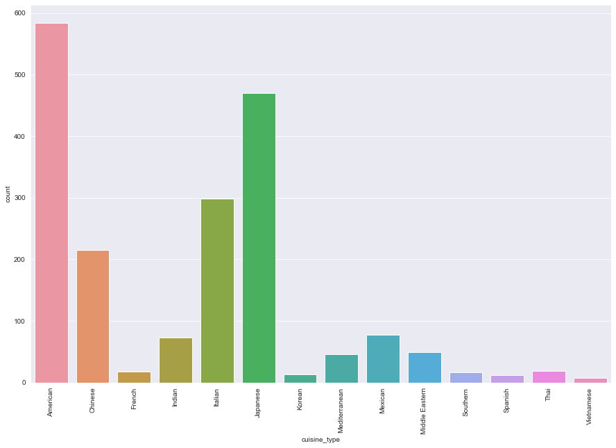

```python
plt.figure(figsize=(15,10)) # to resize the plot

plt.xticks(rotation=90) # to rotate the x axis

sns.countplot(df['cuisine_type']) # plot to show counts of the cuisine_type variable

plt.show() # to show the plot
```

#### Observation:

. From the above visualization, it is observed that the American cuisine has the most orders and the Vietnamese has the lowest orders.

```python
top_5 = df2['restaurant_name'].value_counts() # code to count unique restaurant name in the data set

top_5.head() # code to find the top 5 restaurants in the data set
```

```
Shake Shack                  219
The Meatball Shop            132
Blue Ribbon Sushi            119
Blue Ribbon Fried Chicken     96
Parm                          68
Name: restaurant_name, dtype: int64
```

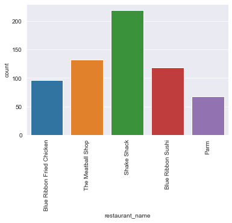

```python
# to plot the top 5 restaurant names in the data set

sns.countplot(x='restaurant_name',
            data=df2[df2["restaurant_name"].isin(["Shake Shack","The Meatball Shop","Blue Ribbon Sushi","Blue Ribbon Fried Chicken","Parm"])])

plt.xticks(rotation=90) # to rotate the axis by 90

plt.show() # to show the plot
```

#### Observation:

. The top 5 restaurant names are Shake Shack, The Meatball Shop, Blue Ribbon Sushi, Blue Ribbon Fried Chicken and Parm.

. Shake Shack and The Meatball Shop are where food are ordered the most.

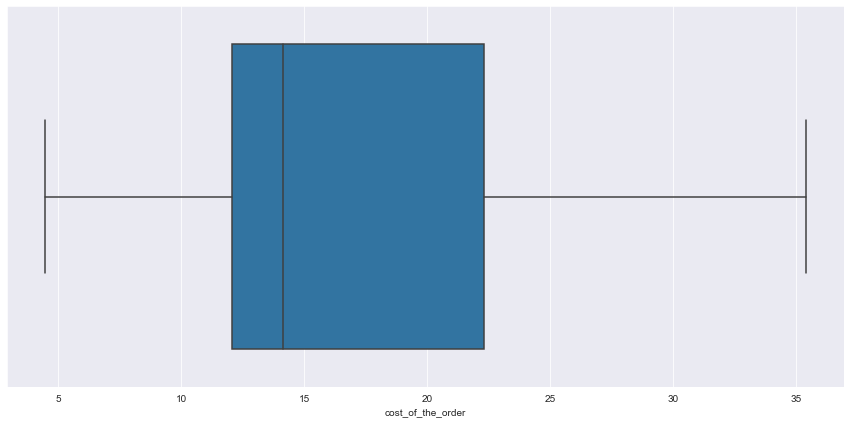

```python
plt.figure(figsize=(15, 7)) # to resize the plot

sns.boxplot(df.cost_of_the_order) # to plot the central tendency of the continuous variable, cost of the order

plt.show() # to show the plot
```

#### Observation:

. The distribution cost of the order seems to be right skewed.

. The median cost of order is less than 15 dollars.

. There are more datapoints at the 3rd quartile of the boxplot.

. The minimum order is less than 5 dollars and the maximum order is above 35 dollars.

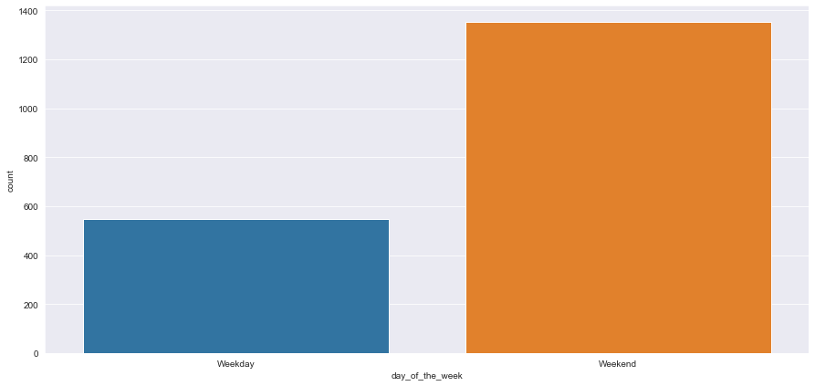

```python
plt.figure(figsize=(15,7)) # to resize the plot

sns.countplot(x ='day_of_the_week' ,data=df) # to plot the count of the variable day of the week

plt.show() # to show the plot
```

#### Observation:

. From the above visualization, most orders are on Weekends.

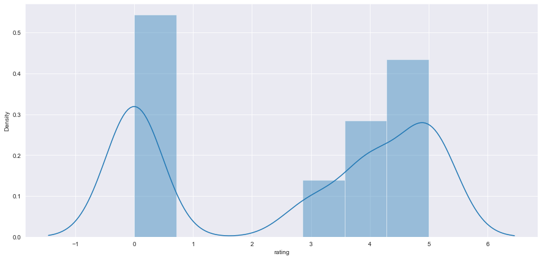

```python
plt.figure(figsize=(15,7)) # to resize the plot

sns.distplot(df['rating']) # to visualize the distribution of the rating variable

plt.show() # to show the plot
```

#### Observation:

. The rating variable has more not given values, this has been represented as 0.

. It further signifies customers are quite reluctant to give ratings after delivery.

. It is difficult to understand the nature of the variable but it is more of a bimodal distrbution.

. The maximum rating 5 is common among the customers.

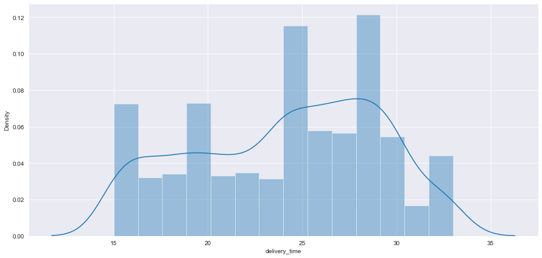

```python
plt.figure(figsize=(15,7)) # to resize the plot

sns.distplot(df['delivery_time']) # to plot the distribution of the delivery time column

plt.show() # to show the plot
```

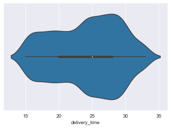

```python
sns.violinplot(x='delivery_time',data=df2) # violin plot to show the distribution of data

plt.show() # to show the plot
```

#### Observation:

. The variable, delivery time is evenly distributed.

. The maximum time of delivery less than 35 minutes.

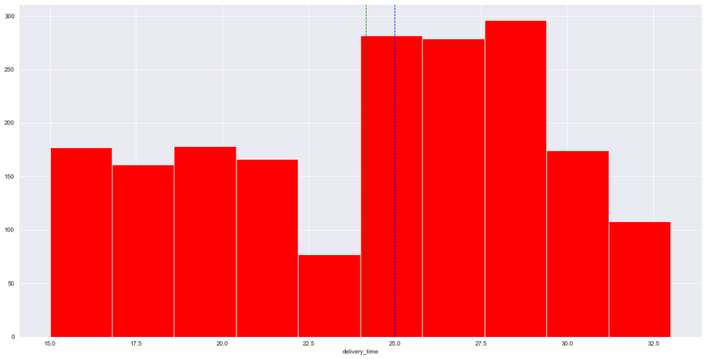

```python
plt.figure(figsize=(20,10)) # makes the plot wider

plt.hist(df['delivery_time'], color='r') # plots a simple histogram

plt.axvline(df['delivery_time'].mean(), color='g', linestyle='dashed' , linewidth=1) # to plot a vertical dashed line showing the mean

plt.axvline(df['delivery_time'].median(), color='b', linestyle='dashed', linewidth=1) # to plot a vertical dashed line showing the median

plt.xlabel('delivery_time')

plt.show() #display the plot
```

#### Observation:

. The mean and median of the delivery time variable are close to each other.

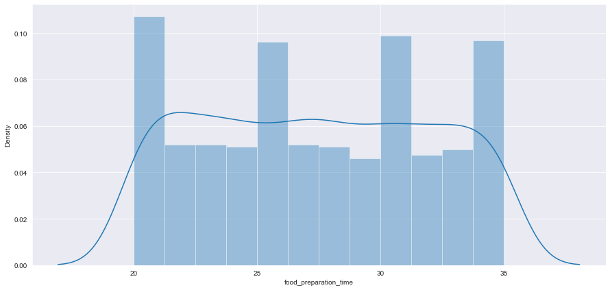

```python
plt.figure(figsize=(15,7)) # to resize the plot

sns.distplot(df['food_preparation_time']) # to plot the distribution of the food preparation time column

plt.show() # to show the plot
```

#### Observation:

. The visualization above shows an evenly spread distribution.

. It shows it often takes 20 minutes to prepare customer's orders.

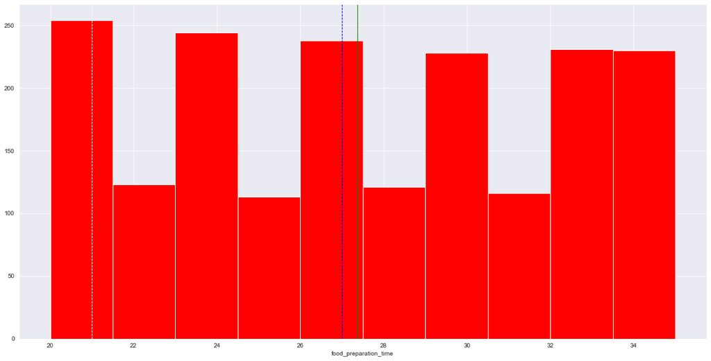

```python
plt.figure(figsize=(20,10)) # makes the plot wider

plt.hist(df['food_preparation_time'], color='r') # plots a simple histogram

plt.axvline(df['food_preparation_time'].mean(), color='g', linewidth=1) # to plot a vertical line showing the mean

plt.axvline(df['food_preparation_time'].median(), color='b', linestyle='dashed', linewidth=1) # to plot a vertical axis showing the median

plt.axvline(df['food_preparation_time'].mode()[0], color='w', linestyle='dashed', linewidth=1) # to plot a vertical axis showing the mode

plt.xlabel('food_preparation_time')

plt.show() # to show the plot
```

#### Observation:

. From the above plot, it frequently takes 20 minutes to prepare customer's orders and above 26 minutes on average.

### Question 7: Write the code to find the top 5 restaurants that have received the highest number of orders. (1 mark)

```python
# code to count number of unique rows of a column

highest_orders_5 = df2.restaurant_name.value_counts()[:5].sort_values(ascending=False)

highest_orders_5 # print out series
```

```
Shake Shack                  219
The Meatball Shop            132
Blue Ribbon Sushi            119
Blue Ribbon Fried Chicken     96
Parm                          68
Name: restaurant_name, dtype: int64
```

#### Observations:

. Shake Shack has the highest number of rows in respect to the restaurant_name column, this indicates it received the highest number of orders.

. The Meatball Shop, Blue Ribbon Sushi, Blue Ribbon Fried Chicken and Parm makes up the top 5 restaurants.

### Question 8: Write the code to find the most popular cuisine on weekends. (1 mark)

```python
# saves the value Weekend from the day_of_the_week column to the variable popular_weekend

popular_cuisine = df.loc[(df2['day_of_the_week']=="Weekend")]

# code to find the  popular cuisine on weekends using groupby and value_counts

popular_cuisine.groupby(['cuisine_type'])['day_of_the_week'].value_counts().sort_values(ascending=False)
```

```
cuisine_type    day_of_the_week
American        Weekend            415
Japanese        Weekend            335
Italian         Weekend            207
Chinese         Weekend            163
Mexican         Weekend             53
Indian          Weekend             49
Middle Eastern  Weekend             32
Mediterranean   Weekend             32
Thai            Weekend             15
French          Weekend             13
Spanish         Weekend             11
Southern        Weekend             11
Korean          Weekend             11
Vietnamese      Weekend              4
Name: day_of_the_week, dtype: int64
```

```python
# code to find the most popular cuisine on weekends using groupby and value_counts

popular_cuisine.groupby(['cuisine_type'])['day_of_the_week'].value_counts()[:1].sort_values(ascending=False)
```

```
cuisine_type  day_of_the_week
American      Weekend            415
Name: day_of_the_week, dtype: int64
```

#### Observations:

. The most popular cuisine on Weekend is American cuisine with 415 orders.

### Question 9: Write the code to find the number of total orders where the cost is above 20 dollars. What is the percentage of such orders in the dataset? (1 mark)

```python
len(df[df['cost_of_the_order'] > 20]) # code to find the length of cost_of_the_order column for orders greater than 20
```

```
555
```

```python
cost = df['cost_of_the_order'] > 20 # to create a variable cost to store cost of orders above 20 dollars

cost.value_counts(normalize=True,ascending=True) # to find the proportion of the cost variable
```

```
True    0.29241
False   0.70759
Name: cost_of_the_order, dtype: float64
```

#### Observations:

. There are 555 orders placed whose cost is above 20 dollars.

. This is equivalent to 29.2% of orders above 20 dollars in the dataset.

### Question 10: Write the code to find the mean delivery time based on this dataset. (1 mark)

```python
df.delivery_time.mean() # code to find the average delivery time using mean function
```

```
24.161749209694417
```

#### Observations:

. The average time for delivery in this dataset is approximately 24 minutes.

### Question 11: Suppose the company has decided to give a free coupon of 15 dollars to the customer who has spent the maximum amount on a single order. Write the code to find the ID of the customer along with the order details. (1 mark)

```python
# code to find the customer with the maximum single order using the max() function

df2[df2['cost_of_the_order'] == df2['cost_of_the_order'].max()]
```

|  | order_id | customer_id | restaurant_name | cuisine_type | cost_of_the_order | day_of_the_week | rating | food_preparation_time | delivery_time |
| --- | --- | --- | --- | --- | --- | --- | --- | --- | --- |
| 573 | 1477814 | 62359 | Pylos | Mediterranean | 35.41000 | Weekday | 4 | 21 | 29 |

#### Observations:

. The order was from a restaurant named Pylos , the cuisine type was Mediterranean on a Weekday.

. The food preparation time was 21 minutes and the delivery time was 29 minutes.

### Question 12: Perform bivariate/multivariate analysis to explore relationships between the important variables in the dataset. (7 marks)

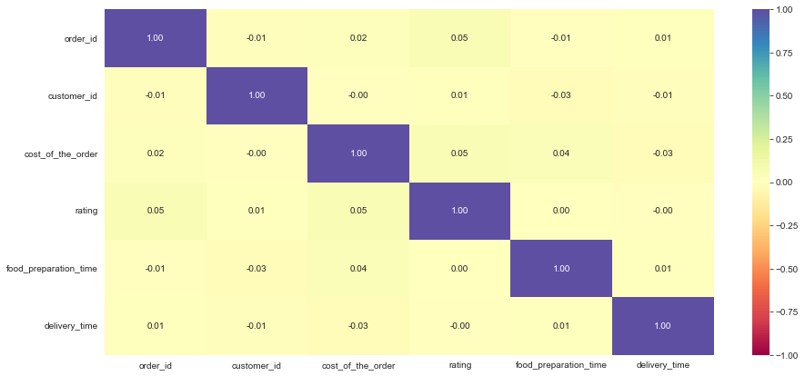

```python
plt.figure(figsize=(15, 7)) # to resize the plot

sns.heatmap(df.corr(), annot=True, vmin=-1, vmax=1, fmt=".2f",cmap="Spectral") # heat map showing correlation between continuous variables.

plt.show() # to show the plot
```

#### Observation:

. There is a positive correlation between rating and cost of order but it is low.

. Food preparation time has no high correlation with any features in the data set.

. Delivery time has low correlation with any features in the data set.

. There is no significant correlation between the features.

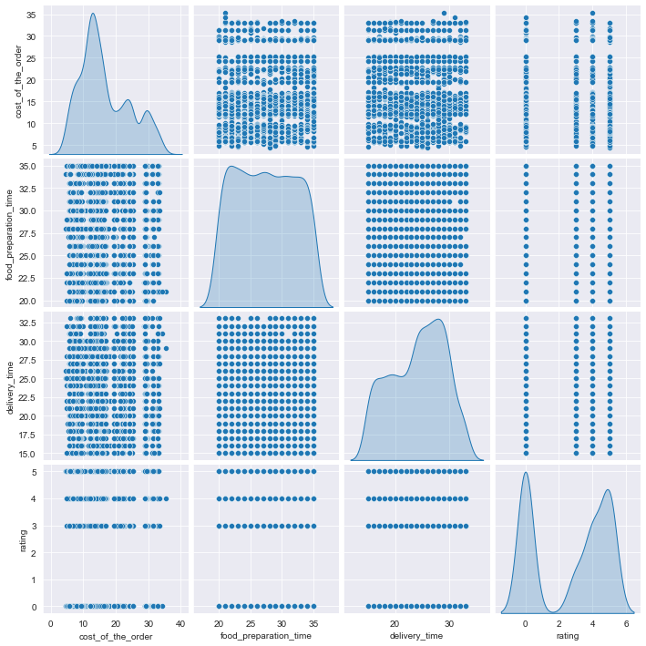

```python
numerical_var = ['cost_of_the_order','food_preparation_time','delivery_time','rating'] # to create a variable to store the required features in the data set

sns.pairplot(data = df[numerical_var], diag_kind = "kde", kind = "scatter") # to plot a pair plot to show relationship between the continuous variable

plt.show() # to show the plot
```

#### Observation:

. The pair plot also indcates there is little correlation with the variables in the dataset.

. The delivery time and food preparation time takes almost the time.

. The data across the variables are evenly distributed. The data needs to be further investigated.

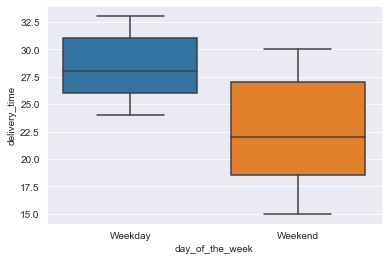

```python
sns.boxplot(x ='day_of_the_week',y ='delivery_time',data = df) # box plot between a categorical variable and a continuous variable

plt.show() # to show the plot
```

#### Observation:

. On Weekdays, the median delivery team is above 27. minutes.

. On Weekends, the median delivery time is above 20 minutes.

. The minimum and maximum delivery time are 15 minutes and 30 minutes respectively on Weekends.

. This indicates orders are delivered faster on Weekends.

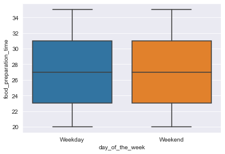

```python
# to plot relationship between the day of the week and food preparation time

sns.boxplot(x='day_of_the_week',y='food_preparation_time',data=df)

plt.show() # to show the plot
```

#### Observation:

. On Weekdays an Weekends , it takes the same time to prepare the food ordered. No possible outliers.

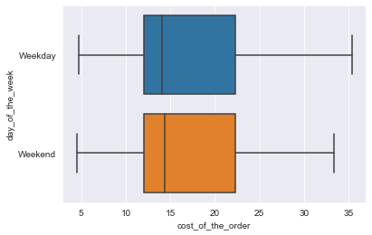

```python
# to plot the relationship the cost of the order and day of the week

sns.boxplot(x='cost_of_the_order',y='day_of_the_week',data=df)

plt.show() # to show the plot
```

#### Observation:

. The cost of order placed on Weekdays and Weekends are almost the same.

. The maximum cost of order was placed on Weekdays according to the visualization above.

. The minimum cost of order was placed on the Weekend.

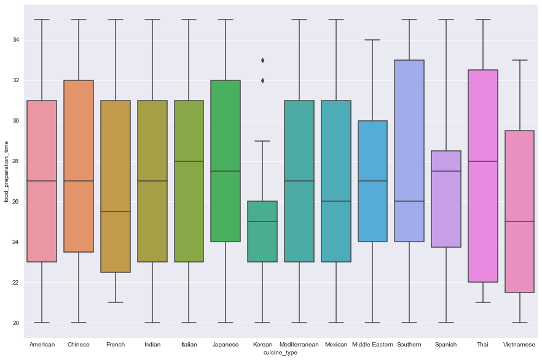

```python
plt.figure(figsize=(15,10)) # to  resize the plot

# to show the frequency of cuisine type in relation to the food preparation time

sns.boxplot(data = df,x='cuisine_type',y='food_preparation_time')

plt.show() # to show the plot
```

#### Observation:

. Most cuisine type has a minimum food preparation time of 20 minutes.

. Most cuisine type has a maximum food preparation time up to 35 minutes.

. The Korean cuisine type has got outliers, which might mean some restaurant take more time than usual.

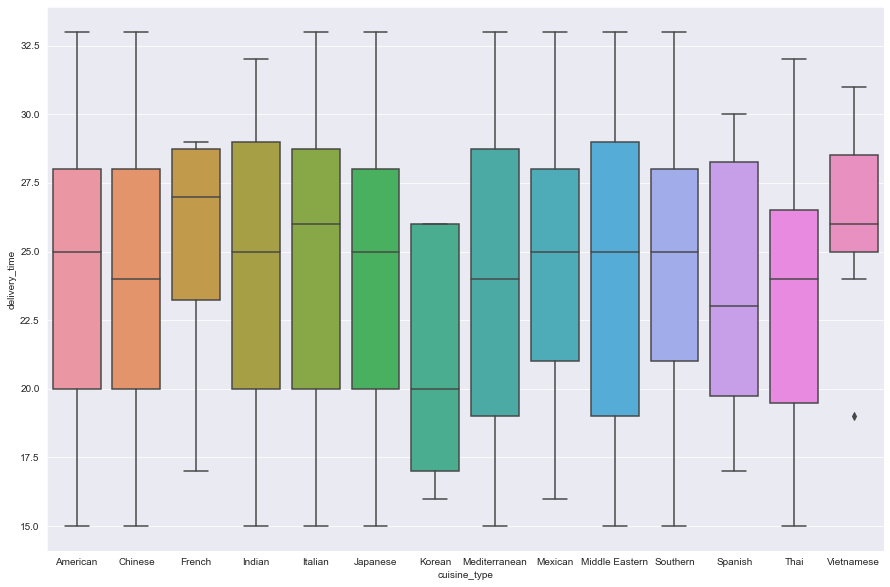

```python
plt.figure(figsize=(15,10)) # to  resize the plot

# to show the frequency of cuisine type in relation to the food preparation time

sns.boxplot(data = df,x='cuisine_type',y='delivery_time')

plt.show()
```

#### Observation:

. The minimum delivery time for most cuisine type is 15 minutes.

. The maximum delivery time for most cuisine type is above 30 minutes.

. The median delivery time is around 25 minutes.

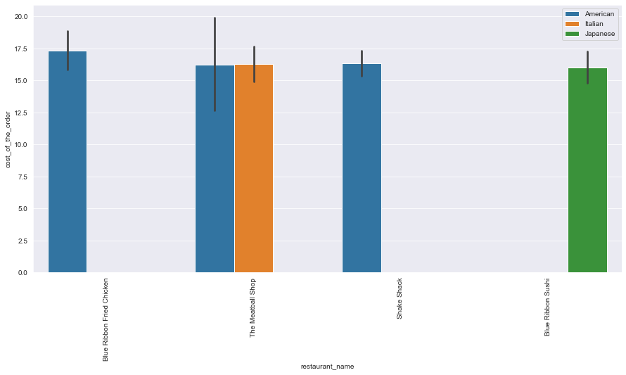

```python
plt.figure(figsize=(15,7)) # to  resize the plot

# plot to show the top 5 restaurant cuisine types in relation to their cost

sns.barplot(x='restaurant_name', y='cost_of_the_order',
            data=df2[df2["restaurant_name"].isin(["Shake Shack","The Meatball Shop","Blue Ribbon Sushi","Blue Ribbon Fried Chicken"])],hue="cuisine_type")

plt.xticks(rotation=90) #to rotate the x axis

plt.legend(loc='upper right') # to place the variable cuisine type

plt.show() # to show the plot
```

#### Observation:

. The top 5 retaurants has only three cuisine type available.

. The cuisine types are American, Italian and Japanese.

. The American cuisine type is the most ordered with a high cost.

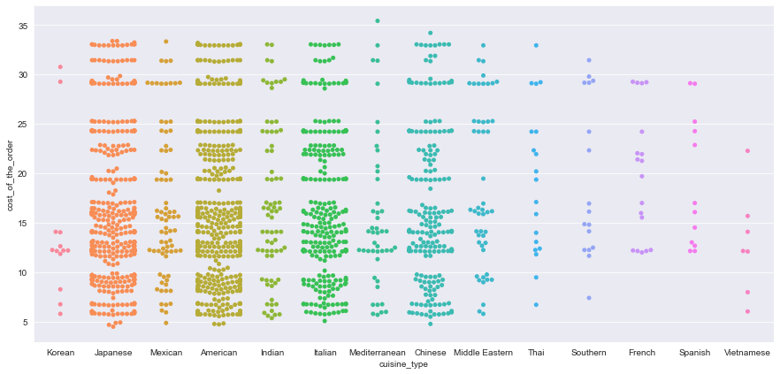

```python
plt.figure(figsize=(15,7)) # to resize the plot

sns.swarmplot(x='cuisine_type',y='cost_of_the_order',data=df2) # to plot swarmplot on cuisine type

plt.show() # to show the plot
```

#### Observation:

. The Japanese, Mexican, American, Indian, Italian, Mediterranean, Chinese cuisine type generates are ordered the most which in way increases revenue for the company.

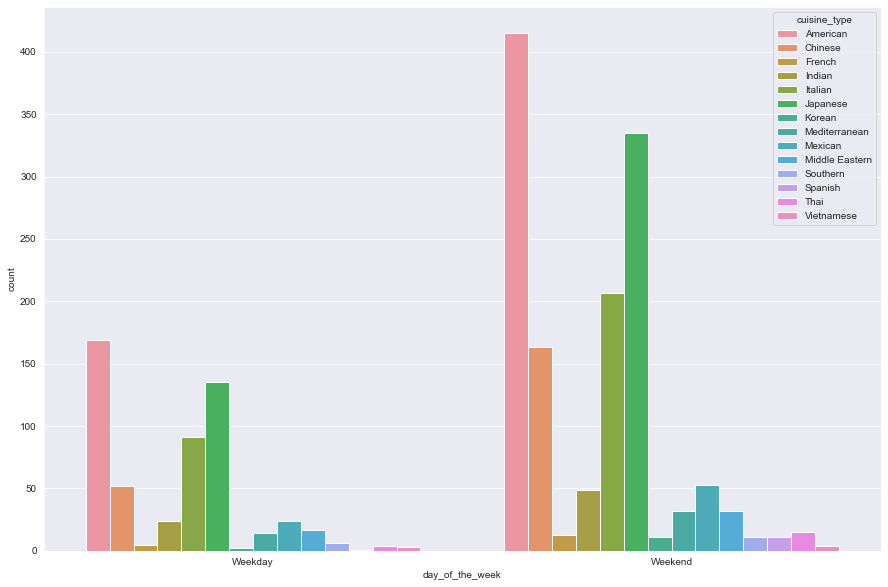

```python
plt.figure(figsize=(15,10)) # to  resize the plot

sns.countplot(x='day_of_the_week',data=df,hue='cuisine_type') # to count number of cuisine type in respect to day of the week

plt.show() # to show the plot
```

#### Observation:

. The American cuisine is the most ordered on Weekdays and Weekends.

### Question 13: Suppose the company wants to provide a promotional offer in the advertisement of the restaurants. The condition to get the offer is that the restaurants must have a rating count of more than 50 and the average rating should be greater than 4. Write the code to find the restaurants fulfilling the criteria to get the promotional offer. (2 marks)

```python
 # to create a variable to store the average rating of restaurant

ratings = df.groupby(['restaurant_name'])['rating'].mean().sort_values(ascending=False).reset_index()

ratings # display dataframe showing average ratings of unique restaurants
```

|  | restaurant_name | rating |
| --- | --- | --- |
| 0 | 'wichcraft | 5.00000 |
| 1 | Klong | 5.00000 |
| 2 | Taro Sushi | 5.00000 |
| 3 | Hunan Manor | 5.00000 |
| 4 | Big Daddy's | 5.00000 |
| ... | ... | ... |
| 173 | Hiroko's Place | 0.00000 |
| 174 | Hangawi | 0.00000 |
| 175 | Gaia Italian Cafe | 0.00000 |
| 176 | Friend of a Farmer | 0.00000 |
| 177 | La Follia | 0.00000 |

178 rows × 2 columns

#### Observation:

. There are 178 unique restaurants with an average rating.

.There are zero ratings which indicates the ratings where not given by the customers.

```python
df['rating'] = df[df['rating'] !=0] # to ignore 0's in the rating column

# to group the restaurant name and rating with the number of rating counts

rating_count = df.groupby(['restaurant_name'])['rating'].count().reset_index()

# to sort the rating values in descending order

rating_count.sort_values(by='rating',ascending=False)
```

|  | restaurant_name | rating |
| --- | --- | --- |
| 136 | Shake Shack | 133 |
| 153 | The Meatball Shop | 84 |
| 21 | Blue Ribbon Sushi | 73 |
| 20 | Blue Ribbon Fried Chicken | 64 |
| 121 | RedFarm Broadway | 41 |
| ... | ... | ... |
| 96 | Market Table | 0 |
| 110 | Paul & Jimmy's | 0 |
| 124 | Room Service | 0 |
| 123 | Rohm Thai | 0 |
| 89 | Lamarca Pasta | 0 |

178 rows × 2 columns

```python
# to join the ratings and rating_count dataframe using merge method

df_merge = ratings.merge(rating_count, on = 'restaurant_name', how = 'inner')

# to sort the merged rating column in descending order

df_merge.sort_values(by='rating_y',ascending=False)
```

|  | restaurant_name | rating_x | rating_y |
| --- | --- | --- | --- |
| 97 | Shake Shack | 2.59817 | 133 |
| 77 | The Meatball Shop | 2.87121 | 84 |
| 98 | Blue Ribbon Sushi | 2.58824 | 73 |
| 76 | Blue Ribbon Fried Chicken | 2.88542 | 64 |
| 72 | RedFarm Broadway | 2.94915 | 41 |
| ... | ... | ... | ... |
| 160 | Emporio | 0.00000 | 0 |
| 159 | Aurora | 0.00000 | 0 |
| 157 | Wa Jeal | 0.00000 | 0 |
| 156 | Alidoro | 0.00000 | 0 |
| 177 | La Follia | 0.00000 | 0 |

178 rows × 3 columns

```python
# to extract data point with conditional statement using loc method

df_merge.loc[(df_merge['rating_x'] > 4) & (df_merge['rating_y'] > 50)]
```

|  | restaurant_name | rating_x | rating_y |
| --- | --- | --- | --- |

#### Observations:

. There are 178 unique restaurants.

. There are missing values in the rating column are represented as 0.

. The top 5 rated restaurants in the dataset have an average rating of 3. This might be due to customers not giving ratings.

. There are no restaurants with rating count above 50 with an average rating above 4.

. Therefore, no restaurant is qualified for the promotional offer.

### Question 14: Suppose the company charges the restaurant 25% on the orders having cost greater than 20 dollars and 15% on the orders having cost greater than 5 dollars. Write the code to find the net revenue generated on all the orders given in the dataset. (2 marks)

```python
# code to define a function to calculate company charges on the cost of the order

def company_charges(cost_order):
        if cost_order > 20:
            return 0.25 * cost_order  # 25% of the cost of the order
        elif cost_order < 20:
            return 0.15 * cost_order  # 15% of the cost of the order
        elif cost_order > 5:
            return 0.15 * cost_order # 15% of the cost of the order

# apply the function on the cost of order column using the apply() method and assign it a variable
company_revenue= df2['cost_of_the_order'].apply(company_charges)

print(company_revenue.tail()) # to print the series
```

```
1893   5.57750
1894   1.82700
1895   6.30500
1896   1.82700
1897   2.91750
Name: cost_of_the_order, dtype: float64
```

```python
company_revenue.sum() # add up the series
```

```
6172.714
```

### Question 15: Suppose the company wants to analyze the total time required to deliver the food. Write the code to find out the percentage of orders that have more than 60 minutes of total delivery time. (2 marks)

Note: The total delivery time is the summation of the food preparation time and delivery time.

```python
# to create a total delivery which is the summation of the food preparationn and delivery time

df2['total_delivery_time'] = df2['food_preparation_time'] + df2['delivery_time']

# to show the first five rows of the dataset

df2.head()
```

|  | order_id | customer_id | restaurant_name | cuisine_type | cost_of_the_order | day_of_the_week | rating | food_preparation_time | delivery_time | total_delivery_time |
| --- | --- | --- | --- | --- | --- | --- | --- | --- | --- | --- |
| 0 | 1477147 | 337525 | Hangawi | Korean | 30.75000 | Weekend | Not given | 25 | 20 | 45 |
| 1 | 1477685 | 358141 | Blue Ribbon Sushi Izakaya | Japanese | 12.08000 | Weekend | Not given | 25 | 23 | 48 |
| 2 | 1477070 | 66393 | Cafe Habana | Mexican | 12.23000 | Weekday | 5 | 23 | 28 | 51 |
| 3 | 1477334 | 106968 | Blue Ribbon Fried Chicken | American | 29.20000 | Weekend | 3 | 25 | 15 | 40 |
| 4 | 1478249 | 76942 | Dirty Bird to Go | American | 11.59000 | Weekday | 4 | 25 | 24 | 49 |

```python
# to find the data points in the total delivery time variable greater than 60

count_delivery_time = df2[df2["total_delivery_time"]>60]

count_delivery_time.head() # display the first 5
```

|  | order_id | customer_id | restaurant_name | cuisine_type | cost_of_the_order | day_of_the_week | rating | food_preparation_time | delivery_time | total_delivery_time |
| --- | --- | --- | --- | --- | --- | --- | --- | --- | --- | --- |
| 7 | 1477859 | 89574 | Barbounia | Mediterranean | 5.97000 | Weekday | 3 | 33 | 30 | 63 |
| 10 | 1477895 | 143926 | Big Wong Restaurant _¤¾Ñ¼ | Chinese | 5.92000 | Weekday | Not given | 34 | 28 | 62 |
| 19 | 1477354 | 67487 | Blue Ribbon Sushi | Japanese | 16.20000 | Weekend | 4 | 35 | 26 | 61 |
| 24 | 1476714 | 363783 | Cafe Mogador | Middle Eastern | 15.86000 | Weekday | Not given | 32 | 29 | 61 |
| 54 | 1477760 | 130507 | Jack's Wife Freda | Mediterranean | 22.75000 | Weekend | 3 | 35 | 29 | 64 |

```python
total_delivery_60 = count_delivery_time['total_delivery_time'].count() # count number of total delivery time above 60 minutes

print('Orders with total delivery above 60 minutes:', total_delivery_60)

total_delivery_all = df2.total_delivery_time.count()  # count number of total delivery

print('Orders with total delivery:',total_delivery_all)

percent_100 = (total_delivery_60 / total_delivery_all * 100).round(1) # total delivery time under 60 in percentage

print(percent_100 ,'%')
```

```
Orders with total delivery above 60 minutes: 200
Orders with total delivery: 1898
10.5 %
```

#### Observations:

. There are 10.5% of total deliveries above 60 minutes.

. The total delivery involves the food preparation time and delivery time added together

### Question 16: Suppose the company wants to analyze the delivery time of the orders on weekdays and weekends. Write the code to find the mean delivery time on weekdays and weekends. Write your observations on the results. (2 marks)

```python
df.groupby(['day_of_the_week'])['delivery_time'].mean() # code to find average delivery time from the day of the week column
```

```
day_of_the_week
Weekday   28.34004
Weekend   22.47002
Name: delivery_time, dtype: float64
```

#### Observations:

. The average delivery time on Weekends is less than the average delivery time on Weekdays.

. Deliveries are quite fast during the weekend.

### Conclusion and Recommendations

### **Question 17:** Write the conclusions and business recommendations derived from the analysis. (3 marks)

#### Key Insights:

. There are 178 different restaurants in the dataset.

. About 39% of ratings where not given, this made it difficult to point out customers preferred restaurants.

. The restaurants with highest number of orders; Shake Shack, The Meatball Shop, Blue Ribbon Sushi,Blue Ribbon Fried Chicken and Parm has a customer rating of less than 3. This might be due to less customer ratings.

. The most ordered cuisine type from the restaurants on Weekday and Weekend was American.

. The least ordered cuisine type was Vietnemese.

. Food is ordered frequently during the Weekend.

. The food preparation time and delivery are evenly distributed. On average it takes about 27 minutes to prepare the food and 24 minutes to deliver.

. It took approximately 50 minutes in food preparation and delivery time to deliver the customer who spent the maximum amount on a single order. A rating of 4 was recorded.

. On Weekend, food is delivered faster than during Weekday. This shows a sign of efficiency during the Weekend.

. The food preparation time depends on the cuisine type.

. The top restaurants have cuisine type American, Italian and Japanese.

. There was no restaurant that could meet up with the company promotional offer due to insufficient customer rating.

. Total delivery time above 60 minutes is around 10.5% in the dataset. This shows that most customer orders are being delivered in less than an hour.

#### Recommendations:

. Customers should be encouraged to give ratings after delivery.

. The delivery time on Weekdays should be monitored and improved, as delivery time on Weekdays take longer.

. More emphasis should be focused on Weekdays as most revenue is generated on Weekends.

. Restaurants should be flexible with their cuisine type.The restaurants have limited number of cuisine type, which increased the orders for a particular restaurant.

. Restaurants with least amount of orders should also be given promotional offers. As observed in the dataset, restaurants with most orders have lesser rating.

. Restaurants with cuisine type American, Japanese, Italian, Indian, Chinese, Mediterranean are ordered most by customers. Restaurants should focus on quality of food and food preparation time.

. The cuisine type in different restaurants should be monitored. The cost of this cuisine type helps generate net revenue.

. Finally, the total delivery time which includes the food preparation time and delivery time should be encouraged to be less than 60 minutes. About 10% of deliveries are above 60 minutes.